# archivist - reprodukowalność

Konrad Komisarczyk, Mariusz Słapek

16.03.2020

# 1 Załączamy pakiet

```r
library(archivist)
```

# 2 Zarządzanie repozytoriami

## 2.1 Tworzenie nowego repozytorium

```r
repo <- "arepo"
createLocalRepo(repoDir = repo, default = TRUE, force=TRUE)
```

```
## Directory arepo does exist and contain the backpack.db file. Reinitialized due to force=TRUE.
```

Wynik polecenia:

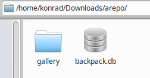

Repozytorium rzeczywiście powstaje.

## 2.2 Usuwanie stworzonego repozytorium

Usuwamy przed chwilą stworzone repozytorium:

[figure not shown]

```r
deleteLocalRepo(repoDir = repo)
```

## 2.3 Kopiowanie zmiennych z innego repozytorium

```r
## Copying artifacts from other repositories
repo <- "arepo"
createLocalRepo(repoDir = repo, default = TRUE)
copyRemoteRepo(repoTo = repo, md5hashes= "7f3453331910e3f321ef97d87adb5bad",
               user = "pbiecek", repo = "graphGallery", repoType = "github")
```

Wynik polecenia:

[figure not shown]

Ponadto można stworzyć archiwum zip zawierające całe repozytorium funkcjami `zipLocalRepo` i `zipRemoteRepo`.

## 2.4 Statystyki repozytorium

```r
showLocalRepo(repoDir = repo, method = "tags")
```

| artifact | tag | createdDate |
| --- | --- | --- |
| 7f3453331910e3f321ef97d87adb5bad | format:rda | 2016-12-31 15:50:59 |
| 7f3453331910e3f321ef97d87adb5bad | name:pl1 | 2016-12-31 15:50:59 |
| 7f3453331910e3f321ef97d87adb5bad | class:gg | 2016-12-31 15:50:59 |
| 7f3453331910e3f321ef97d87adb5bad | class:ggplot | 2016-12-31 15:50:59 |
| 7f3453331910e3f321ef97d87adb5bad | labelx:Sepal.Length | 2016-12-31 15:50:59 |
| 7f3453331910e3f321ef97d87adb5bad | labely:Petal.Length | 2016-12-31 15:50:59 |
| 7f3453331910e3f321ef97d87adb5bad | date:2016-12-31 15:50:59 | 2016-12-31 15:50:59 |
| 7f3453331910e3f321ef97d87adb5bad | session_info:0c325724f6118fdd80e6504204b72cfa | 2016-12-31 15:50:59 |
| 7f3453331910e3f321ef97d87adb5bad | format:png | 2016-12-31 15:51:00 |

```r
summaryLocalRepo(repoDir =
                     system.file("graphGallery", package = "archivist"))
```

```
## Number of archived artifacts in Repository:  9
## Number of archived datasets in Repository:  5
## Number of various classes archived in Repository:
##             Number
## lm              5
## data.frame      2
## summary.lm      1
## gg              2
## ggplot          2
## Saves per day in Repository:
##             Saves
## 2016-02-07     5
## 2016-02-08    13
## 2016-03-04     3
## 2016-12-31     4
## 2017-11-21     2
## 2020-03-17     5
```

Wynik jest inny niż w publikacji, są dwa zapisy 21.11.2017, których nie ma w publikaci.

## 2.5 Ustawianie domyślnego repozytorium

```r
setRemoteRepo(user = "pbiecek", repo = "graphGallery", repoType = "github")
```

```r
setLocalRepo(repoDir = system.file("graphGallery", package = "archivist"))
```

Po ustawieniu domyślnych repozytoriów możemy podawać mniej argumentów funkcjom zapisującym i odczytującym z repozytorium:

```r
setLocalRepo(repoDir = repo)
data("iris", package = "datasets")
saveToLocalRepo(iris)
```

```
## [1] "d3c5d071001b61a9f6131d3004fd0988"
```

Możemy także zmieniać ustawienia pakietu za pomocą funkcji `aoptions`, np. zmienić domyślny typ repozytorium na repozytorium github:

```r
aoptions("repoType", "github")
```

```
## [1] "github"
```

# 3 Zarządzanie artefaktami

## 3.1 Zapisywanie obiektu do repozytorium

```r
library("ggplot2")
repo <- "arepo"
pl <- qplot(Sepal.Length, Petal.Length, data = iris)
saveToRepo(pl, repoDir = repo)
```

```
## [1] "57cd40eba6097b49c6cad91ff5ec71cf"
## attr(,"data")
## [1] "d3c5d071001b61a9f6131d3004fd0988"
```

```r
showLocalRepo(repoDir = repo, "tags")
```

| artifact | tag | createdDate |
| --- | --- | --- |
| 7f3453331910e3f321ef97d87adb5bad | format:rda | 2016-12-31 15:50:59 |
| 7f3453331910e3f321ef97d87adb5bad | name:pl1 | 2016-12-31 15:50:59 |
| 7f3453331910e3f321ef97d87adb5bad | class:gg | 2016-12-31 15:50:59 |
| 7f3453331910e3f321ef97d87adb5bad | class:ggplot | 2016-12-31 15:50:59 |
| 7f3453331910e3f321ef97d87adb5bad | labelx:Sepal.Length | 2016-12-31 15:50:59 |
| 7f3453331910e3f321ef97d87adb5bad | labely:Petal.Length | 2016-12-31 15:50:59 |
| 7f3453331910e3f321ef97d87adb5bad | date:2016-12-31 15:50:59 | 2016-12-31 15:50:59 |
| 7f3453331910e3f321ef97d87adb5bad | session_info:0c325724f6118fdd80e6504204b72cfa | 2016-12-31 15:50:59 |
| 7f3453331910e3f321ef97d87adb5bad | format:png | 2016-12-31 15:51:00 |
| d3c5d071001b61a9f6131d3004fd0988 | format:rda | 2020-03-17 16:55:53 |

[output cut: 24 more lines]

## 3.2 Sesja powiązana z obiektem

Dla każdego artfaktu możemy zobaczyć informacje o sesji R, w jakiej został stworzony. W przypadku problemu z odtworzeniem wyniku pozwala nam to zobaczyć np. przy jakich wersjach pakietów był on tworzony.

```r
asession("d3c5d071001b61a9f6131d3004fd0988")
```

## 3.3 Rozszerzony pipe

Pakiet `archivist` udostepnia operator `%a%` będący rozszerzeniem operatora `%>%` dodatkowo zapisującym do repo całą historię wywoływanych za jego pomocą funkcji i tworzonych obiektów.

```r
library("archivist")
createLocalRepo("arepo", default = TRUE)
library("dplyr")
iris %a% filter(Sepal.Length < 6) %a%
  lm(Petal.Length ~ Species, data = .) %a% summary() -> tmp
```

Możemy teraz zobaczyć historię obiektu `tmp` na jeden z 2 sposobów:

```r
ahistory(tmp)
```

| md5hash | call |
| --- | --- |
| 050e41ec3bc40b3004bc6bdd356acae7 | summary() |
| 990861c7c27812ee959f10e5f76fe2c3 | lm(Petal.Length ~ Species, data = .) |
| a27916bdf28616e74d696788eccd4764 | filter(Sepal.Length < 6) |
| d3c5d071001b61a9f6131d3004fd0988 | iris |

```r
ahistory(md5hash = "050e41ec3bc40b3004bc6bdd356acae7")
```

| md5hash | call |
| --- | --- |
| 050e41ec3bc40b3004bc6bdd356acae7 | summary() |
| 990861c7c27812ee959f10e5f76fe2c3 | lm(Petal.Length ~ Species, data = .) |
| a27916bdf28616e74d696788eccd4764 | filter(Sepal.Length < 6) |
| d3c5d071001b61a9f6131d3004fd0988 | iris |

## 3.4 Wczytywanie obiektu z repozytorium

```r
loadFromRemoteRepo("7f3453331910e3f321ef97d87adb5bad", repo = "graphGallery", user = "pbiecek",
                   value = TRUE)
```

```r
loadFromLocalRepo("7f3453", system.file("graphGallery", package = "archivist"), value = TRUE)
```

Możemy też skorzystać z wrappera upraszaczającego funkcję wczytywania obiektów:

Z zewnętrznego repozytorium:

```r
archivist::aread("pbiecek/graphGallery/7f3453331910e3f321ef97d87adb5bad")
```

i z lokalnego:

```r
setLocalRepo(system.file("graphGallery", package = "archivist"))
aread("7f3453")
```

Używanie hashy MD5 jako indentyfikatorów obiektów ma m.in. taką zaletę, że możemy policzyć hash obiektu metodą `digest` aby potwierdzić jego autentyczność:

```r
setLocalRepo(system.file("graphGallery", package = "archivist"))
model <- aread("2a6e492cb6982f230e48cf46023e2e4f")
summary(model)
```

```
##
## Call:
## lm(formula = Petal.Length ~ Sepal.Length + Species, data = iris)
##
## Residuals:
##      Min       1Q   Median       3Q      Max
## -0.76390 -0.17875  0.00716  0.17461  0.79954
##
## Coefficients:
##                   Estimate Std. Error t value Pr(>|t|)
## (Intercept)       -1.70234    0.23013  -7.397 1.01e-11 ***
## Sepal.Length       0.63211    0.04527  13.962  < 2e-16 ***
## Speciesversicolor  2.21014    0.07047  31.362  < 2e-16 ***
## Speciesvirginica   3.09000    0.09123  33.870  < 2e-16 ***
## ---
## Signif. codes:  0 '***' 0.001 '**' 0.01 '*' 0.05 '.' 0.1 ' ' 1
##
## Residual standard error: 0.2826 on 146 degrees of freedom
## Multiple R-squared:  0.9749, Adjusted R-squared:  0.9744
## F-statistic:  1890 on 3 and 146 DF,  p-value: < 2.2e-16
```

```r
digest::digest(model)
```

```
## [1] "2a6e492cb6982f230e48cf46023e2e4f"
```

## 3.5 Usuwanie obiektów z repozytorium

Z lokalnego repoytorium możemy obiekty usuwać:

```r
rmFromLocalRepo("7f3453331910e3f321ef97d87adb5bad", repoDir = repo)
```

Możemy też wybrać zbiór artefaktów do usunięcia za pomocą wyszukiwania. Np. usunąć wszystkie obiekty starsze niż miesiąc:

```r
obj2rm <- searchInLocalRepo(list(dateFrom = "2010-01-01", dateTo = Sys.Date() - 30),
                            repoDir = repo)
rmFromLocalRepo(obj2rm, repoDir = repo, many = TRUE)
```

W ten sposób przechodzimy do kolejnego punktu…

# 4 Wyszukiwanie artefaktów

## 4.1 Szukanie w lokalnym i zewnętrzym repo

```r
searchInLocalRepo(pattern = "class:gg",
    repoDir = system.file("graphGallery", package = "archivist"))
```

```
## [1] "7f3453331910e3f321ef97d87adb5bad" "369227e67f9164dcbe934dadf2b53cc2"
```

```r
searchInLocalRepo(pattern = list(dateFrom = "2016-01-01",
    dateTo = "2016-02-07" ),
    repoDir = system.file("graphGallery", package = "archivist"))
```

```
## [1] "d9313a0de3e2980201a8971e3384ff26" "ff575c261c949d073b2895b05d1097c3"
## [3] "2a6e492cb6982f230e48cf46023e2e4f" "93ecfdf1436932e2860c6dbdf2abc2ad"
## [5] "afb2550d0f886f0cf3b050f04c5cd4f8"
```

```r
searchInLocalRepo(pattern = c("class:gg", "labelx:Sepal.Length"),
         repoDir = system.file("graphGallery", package = "archivist"))
```

```
## [1] "369227e67f9164dcbe934dadf2b53cc2" "7f3453331910e3f321ef97d87adb5bad"
```

## 4.2 Wybieranie obiektów po tagach

```r
setLocalRepo(system.file("graphGallery", package = "archivist"))
models <- asearch(patterns = c("class:lm", "coefname:Sepal.Length"))
```

```r
models <- asearch("pbiecek/graphGallery",
    patterns = c("class:lm", "coefname:Sepal.Length"))
lapply(models, coef)
```

```
## $`18a98048f0584469483afb65294ce3ed`
##  (Intercept) Sepal.Length
##    -7.101443     1.858433
##
## $`2a6e492cb6982f230e48cf46023e2e4f`
##       (Intercept)      Sepal.Length Speciesversicolor  Speciesvirginica
##        -1.7023422         0.6321099         2.2101378         3.0900021
```

```r
plots <- asearch(patterns = c("class:gg", "labelx:Sepal.Length"))
length(plots)
```

```
## [1] 2
```

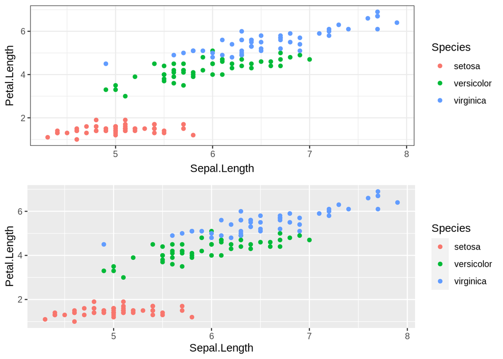

```r
library("gridExtra")
do.call(grid.arrange, plots)
```

## 4.3 Wyszukiwanie interaktywne

```r
arepo <- system.file("graphGallery", package = "archivist")
if (interactive()) {
  shinySearchInLocalRepo(arepo)
}
```

Wynik polecenia:

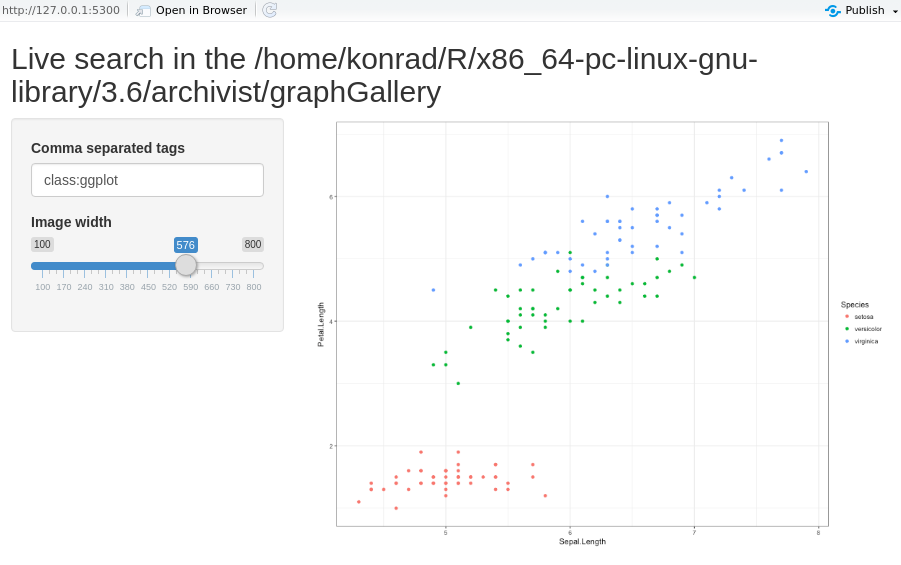

# 5 Rozszerzenia

## 5.1 Archiwizacja wystąpień poszczególnej funkcji

```r
library("archivist")
createLocalRepo("allModels", default = TRUE)
```

```
## Directory allModels does exist and contain the backpack.db file. Use force=TRUE to reinitialize.
```

```r
atrace("lm", "z")
```

```
## Tracing function "lm" in package "stats"
```

```
## [1] "lm"
```

```r
lm(Sepal.Length ~ Sepal.Width, data = iris)
```

```
## Tracing lm(Sepal.Length ~ Sepal.Width, data = iris) on exit
```

```
##
## Call:
## lm(formula = Sepal.Length ~ Sepal.Width, data = iris)
##
## Coefficients:
## (Intercept)  Sepal.Width
##      6.5262      -0.2234
```

Możemy teraz zobaczyć kiedy używaliśmy funkcji “lm”.

```r
sapply(asearch("class:lm"), BIC)
```

```
## 18a98048f0584469483afb65294ce3ed 2a6e492cb6982f230e48cf46023e2e4f
##                        396.16690                         67.52735
## 42fcf77af2c40f70c445cbba513aeabd 5c5751e36b31b2251d2767d96993320a
##                        381.02358                        169.07233
## 990861c7c27812ee959f10e5f76fe2c3
##                         39.05577
```

## 5.2 Integracja z pakietami “knitr”

```r
addHooksToPrint(class = c("ggplot", "data.frame"),
                repoDir = "arepo",
                repo = "Eseje", user = "pbiecek", subdir = "arepo")
```

## 5.3 Galeria artefaktów

Pakiet pozwala dla repozytoriów zewnętrznych przechowywanych na githubie automatycznie wygenerować plik `readme.md` zawierający listę wraz z miniaturkami wszystkich artefaktów.

```r
createMDGallery("arepo/readme.md",
                repo = "Eseje", user = "pbiecek", subdir = "arepo",
                addMiniature = TRUE, addTags = TRUE)
```

# 6 Jedyny nie działający przykład

Jedyny całkowicie nie działający przykład znajduje się na początku artykułu

```r
archivist::aread("pbiecek/Eseje/arepo/65e430c4180e97a704249a56be4a7b88")
```

Wyrzuca nam błąd o treści “Error: Please use `data_frame()` or `new_data_frame()` instead of `data.frame()` for better performance. See the vignette ‘ggplot2 internal programming guidelines’ for details.”.

Kiedy przypiszemy wynik funkcji do zmiennej:

```r
p <- archivist::aread("pbiecek/Eseje/arepo/65e430c4180e97a704249a56be4a7b88")
class(p)
```

```
## [1] "gg"     "ggplot"
```

okazuje, się że zmienna powinna być plotem ggplota. Błąd prawdopodobnie związany jest ze zmianą wersji ggplota. Jednak instalując używane podczas tworzenia artykułu wersje R i pakietów nadal nie udaje nam się wyniku odtworzyć.